# BIOST 537 group project

Hyunhae Lee

2025-11-15

### Variable Preparation

```r
bmt <- read.csv(here::here("data/bmt.csv")) %>%
  mutate(across(c(male, cmv, donorcmv, disgroup, donormale,
                  fab, mtx, hospital),as_factor)) %>%
  mutate(male = ifelse(male==1, "Male", "Female"),
         male = factor(male, levels=c("Female", "Male")),
         donormale = ifelse(donormale==1, "Male", "Female"),
         donormale = factor(donormale, levels=c("Female", "Male")),
         cmv = ifelse(cmv==1, "CMV Positive", "CMV Negative"),
         cmv = factor(cmv,
                      levels=c("CMV Negative", "CMV Positive")),
         donorcmv = ifelse(donorcmv==1, "CMV Positive", "CMV Negative"),
         donorcmv = factor(donorcmv,
                           levels=c("CMV Negative", "CMV Positive")),
         disgroup = case_when(
           disgroup == 1 ~ "ALL",
           disgroup == 2 ~ "AML (Low Risk)",
           disgroup == 3 ~ "AML (High Risk)"),
         disgroup=factor(disgroup,
                         levels =c("ALL",
                                   "AML (Low Risk)",
                                  "AML (High Risk)")),
         fab=ifelse(fab==1, "FAB grade 4 or 5 and AML", "Other"),
         fab=factor(fab, levels =c("Other",
                                   "FAB grade 4 or 5 and AML")),
         mtx = ifelse(mtx==1, "Prophylactic Use of Methotrexate",
                       "No Prophylactic Use of Methotrexate"),
         mtx=factor(mtx, levels=c("No Prophylactic Use of Methotrexate",
                                  "Prophylactic Use of Methotrexate")),
         hospital = case_when(
           hospital == 1 ~ "The Ohio State University",
           hospital == 2 ~ "Alfred (Melbourne, Austrailia)",
           hospital == 3 ~ "St. Vincent (Sydney, Australia)",
           hospital == 4 ~ "AHahnemann (Philadelphia, PA)"))

glimpse(bmt)
```

```
## Rows: 137
## Columns: 22
## $ X         <int> 1, 2, 3, 4, 5, 6, 7, 8, 9, 10, 11, 12, 13, 14, 15, 16, 17, 1…
## $ id        <int> 1, 2, 3, 4, 5, 6, 7, 8, 9, 10, 11, 12, 13, 14, 15, 16, 17, 1…
## $ ts        <int> 2081, 1602, 1496, 1462, 1433, 1377, 1330, 996, 226, 1199, 11…
## $ deltas    <int> 0, 0, 0, 0, 0, 0, 0, 0, 0, 0, 0, 0, 0, 0, 1, 1, 1, 1, 1, 1, …
## $ tdfs      <int> 2081, 1602, 1496, 1462, 1433, 1377, 1330, 996, 226, 1199, 11…
## $ deltar    <int> 0, 0, 0, 0, 0, 0, 0, 0, 0, 0, 0, 0, 0, 0, 0, 1, 0, 1, 1, 0, …
## $ deltadfs  <int> 0, 0, 0, 0, 0, 0, 0, 0, 0, 0, 0, 0, 0, 0, 1, 1, 1, 1, 1, 1, …
## $ ta        <int> 67, 1602, 1496, 70, 1433, 1377, 1330, 72, 226, 1199, 1111, 3…
## $ deltaa    <int> 1, 0, 0, 1, 0, 0, 0, 1, 0, 0, 0, 1, 0, 1, 0, 0, 0, 1, 0, 1, …
## $ tp        <int> 13, 18, 12, 13, 12, 12, 17, 12, 10, 29, 22, 34, 22, 1167, 21…
## $ deltap    <int> 1, 1, 1, 1, 1, 1, 1, 1, 1, 1, 1, 1, 1, 0, 1, 1, 1, 1, 1, 1, …
## $ disgroup  <fct> ALL, ALL, ALL, ALL, ALL, ALL, ALL, ALL, ALL, ALL, ALL, ALL, …
## $ age       <int> 26, 21, 26, 17, 32, 22, 20, 22, 18, 24, 19, 17, 24, 27, 18, …
## $ male      <fct> Male, Male, Male, Female, Male, Male, Male, Male, Female, Ma…
## $ cmv       <fct> CMV Positive, CMV Negative, CMV Positive, CMV Negative, CMV …
## $ donorage  <int> 33, 37, 35, 21, 36, 31, 17, 24, 21, 40, 28, 28, 23, 22, 14, …
## $ donormale <fct> Female, Male, Male, Male, Male, Male, Female, Female, Male, …
## $ donorcmv  <fct> CMV Positive, CMV Negative, CMV Negative, CMV Negative, CMV …
## $ waittime  <int> 98, 1720, 127, 168, 93, 2187, 1006, 1319, 208, 174, 236, 151…
## $ fab       <fct> Other, Other, Other, Other, Other, Other, Other, Other, Othe…
## $ hospital  <chr> "The Ohio State University", "The Ohio State University", "T…
## $ mtx       <fct> No Prophylactic Use of Methotrexate, No Prophylactic Use of …
```

```r
s.dfs <- with(bmt, Surv(time = tdfs, event = deltadfs))
```

### Directive 1

Provide an estimate of disease-free survival time for patients enrolled in this study. What are the main characteristics of this summary?

```r
fit.dfs <- survfit(s.dfs ~ 1,
                   conf.type = "log-log",
                   conf.int  = 0.90, data=bmt)

summary(fit.dfs)
```

```
## Call: survfit(formula = s.dfs ~ 1, data = bmt, conf.type = "log-log",
##     conf.int = 0.9)
##
##  time n.risk n.event survival std.err lower 90% CI upper 90% CI
##     1    137       1    0.993 0.00727        0.963        0.999
##     2    136       1    0.985 0.01025        0.954        0.995
##    10    135       1    0.978 0.01250        0.944        0.991
##    16    134       1    0.971 0.01438        0.935        0.987
##    32    133       1    0.964 0.01602        0.925        0.982
##    35    132       1    0.956 0.01748        0.916        0.977
##    47    131       2    0.942 0.02003        0.898        0.967
##    48    129       2    0.927 0.02222        0.880        0.956
##    53    127       1    0.920 0.02322        0.872        0.950
##    55    126       1    0.912 0.02415        0.863        0.945
##    63    125       1    0.905 0.02504        0.854        0.939
```

[output cut: 65 more lines]

```r
print(fit.dfs)
```

```
## Call: survfit(formula = s.dfs ~ 1, data = bmt, conf.type = "log-log",
##     conf.int = 0.9)
##
##        n events median 0.9LCL 0.9UCL
## [1,] 137     83    481    383    677
```

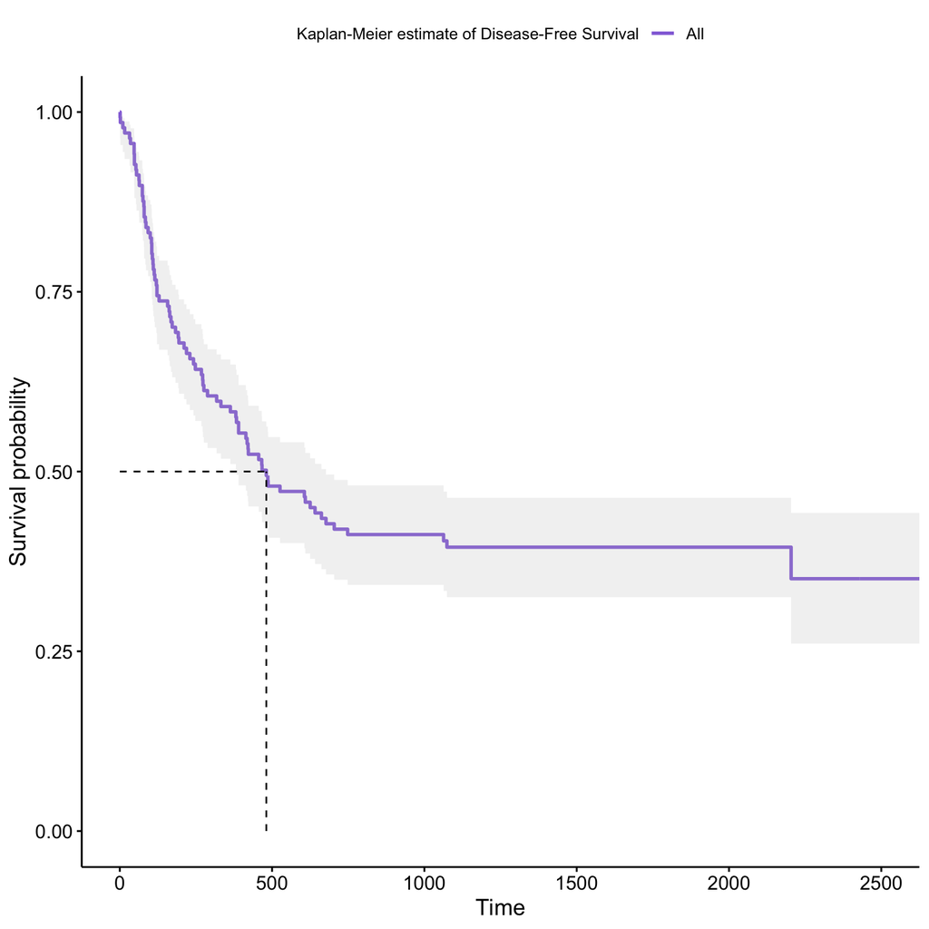

```r
km_plot <- survminer::ggsurvplot(survfit(
  Surv(time = tdfs, event = deltadfs) ~ 1,
                   conf.type = "log-log",
                   conf.int  = 0.90, data=bmt),
                      legend.title="Kaplan-Meier estimate of Disease-Free Survival",
                      data=bmt,
           conf.int=TRUE, censor = FALSE,
           palette = c("#9370DB"),
           conf.int.alpha = 0.2,
           pval=T,surv.median.line="hv")
km_plot
```

```r
ggsave(here::here("figures/km_directive1.png"), plot = km_plot$plot, width = 6, height = 4, dpi = 300)
```

3. We can later think about adding / discussing the restricted mean survival time

```r
source(here::here("scripts/getmedianres.R"))

getmedianres(survobj=s.dfs,times=481,confint=TRUE)
```

```
## $times
## [1] 481
##
## $ci.lower
## [1] 1723
##
## $estimates
## [1] NA
##
## $ci.upper
## [1] 1723
```

```r
cat("The point at which half of them experience the event does not appear in the data\n")
```

```
## The point at which half of them experience the event does not appear in the data
```

## Directive 2

1. How do patients in different *disease groups* compare to each other in baseline measurements and
2. how do patients in different *FAB classifications* compare to each other with respect to other available baseline measurements?

### Variables

Baseline measurements of interest: patient age and sex, donor age and sex, patient and donor cytomegalovirus (CMV) immune status, the wait time from diagnosis to transplantation, disease group, French-American-British (FAB) classification based on standard morphological criteria, and prophylactic use of methotrexate to prevent aGVHD

**Based on**

> > 1. disgroup 1 = ALL ALL refers to ”acute lymphoblastic leukemia” 2 = AML Low Risk AML refers to ”acute myelocytic leukemia 3 = AML High Risk
> > 2. patient CMV status 1 = patient is CMV positive 0 = patient is CMV negative

**characteristics** *continuous* >> age: patient age (in years) donorage: age of donor (in years) waittime: waiting time until transplant (in days)

*categorical* >> - male: indicator of patient being male 1 = patient is male 0 = patient is female - cmv: patient CMV status 1 = patient is CMV positive 0 = patient is CMV negative - donormale: indicator of donor being male 1 = donor is male 0 = donor if female - donorcmv: donor CMV status 1 = donor is CMV positive 0 = donor is CMV negative - fab: disease subtype 1 = FAB grade 4 or 5 and AML 0 = otherwise - hospital: recruitment center 1 = The Ohio State University (Columbus, OH) 2 = Alfred (Melbourne, Austrailia 3 = St. Vincent (Sydney, Australia) 4 = Hahnemann (Philadelphia, PA) - mtx: prophylactic use of methotrexate 1 = yes 0 = no

### Summary: Continuous variables

```r
names(bmt)
```

```
##  [1] "X"         "id"        "ts"        "deltas"    "tdfs"      "deltar"
##  [7] "deltadfs"  "ta"        "deltaa"    "tp"        "deltap"    "disgroup"
## [13] "age"       "male"      "cmv"       "donorage"  "donormale" "donorcmv"
## [19] "waittime"  "fab"       "hospital"  "mtx"
```

```r
bmt <- bmt %>%
  mutate(sex_mismatch = paste0(donormale, "->", male),
         sex_mismatch = ifelse(sex_mismatch == "Male->Male",
                               "Match", sex_mismatch),
         sex_mismatch = ifelse(sex_mismatch == "Female->Female",
                               "Match", sex_mismatch),
         sex_mismatch = factor(
           sex_mismatch,
           levels=c("Match", "Male->Female","Female->Male")),
         cmv_mismatch = paste0(donorcmv, "->", cmv),
         cmv_mismatch = factor(
           cmv_mismatch,
           levels=c("CMV Negative->CMV Negative",
                    "CMV Negative->CMV Positive",
                    "CMV Positive->CMV Negative",
                    "CMV Positive->CMV Positive")))

bmt %>%
  select("age", "donorage", "waittime") %>%
  describe() %>%
  select(skew)
```

```
##          skew
## age      0.30
## donorage 0.07
## waittime 3.86
```

```r
vars <- bmt %>% select("age", "male", "cmv", "donorage",
             "donormale", "donorcmv", "waittime", "fab",
             "hospital", "mtx", "disgroup", "sex_mismatch", "cmv_mismatch", "deltaa",
             "deltas", "deltar")

vars %>%
  tbl_summary() %>%
  as_gt() %>%
  opt_table_font(
    font = list("Times New Roman")) %>%
  tab_options(
    table.font.size = px(10),
    heading.title.font.size = px(10))
```

| **Characteristic** | **N = 137**<sup>1</sup> |
| --- | --- |
| age | 28 (21, 35) |
| male |  |
| Female | 57 (42%) |
| Male | 80 (58%) |
| cmv |  |
| CMV Negative | 69 (50%) |
| CMV Positive | 68 (50%) |
| donorage | 28 (21, 35) |
| donormale |  |
| Female | 49 (36%) |
| Male | 88 (64%) |
| donorcmv |  |
| CMV Negative | 79 (58%) |
| CMV Positive | 58 (42%) |
| waittime | 178 (110, 240) |
| fab |  |
| Other | 92 (67%) |
| FAB grade 4 or 5 and AML | 45 (33%) |
| hospital |  |
| AHahnemann (Philadelphia, PA) | 21 (15%) |
| Alfred (Melbourne, Austrailia) | 17 (12%) |
| St. Vincent (Sydney, Australia) | 23 (17%) |
| The Ohio State University | 76 (55%) |
| mtx |  |
| No Prophylactic Use of Methotrexate | 97 (71%) |
| Prophylactic Use of Methotrexate | 40 (29%) |
| disgroup |  |
| ALL | 38 (28%) |
| AML (Low Risk) | 54 (39%) |
| AML (High Risk) | 45 (33%) |
| sex_mismatch |  |
| Match | 79 (58%) |
| Male->Female | 33 (24%) |
| Female->Male | 25 (18%) |
| cmv_mismatch |  |
| CMV Negative->CMV Negative | 50 (36%) |
| CMV Negative->CMV Positive | 29 (21%) |
| CMV Positive->CMV Negative | 19 (14%) |
| CMV Positive->CMV Positive | 39 (28%) |
| deltaa | 26 (19%) |
| deltas | 81 (59%) |
| deltar | 42 (31%) |

<sup>1</sup> Median (Q1, Q3); n (%)

### Boxplot: continuous variables

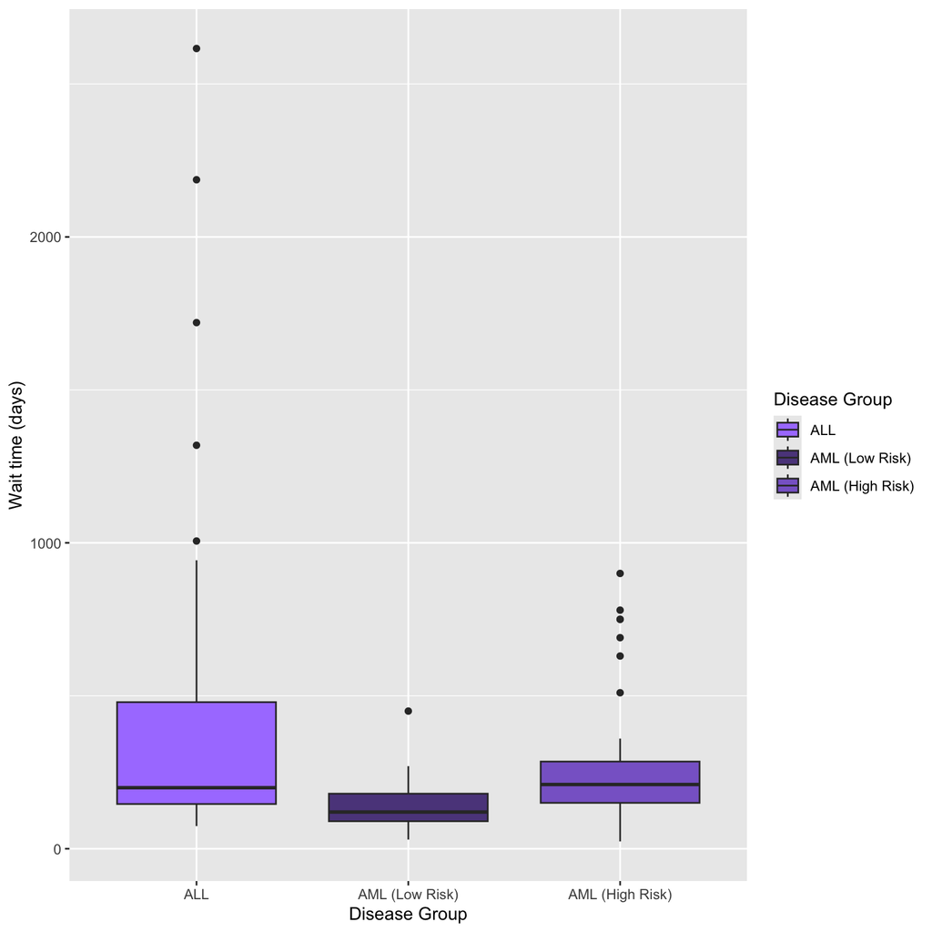

```r
# Disease group - Wait time
p <- ggplot(bmt, aes(x = disgroup, y = waittime, fill=disgroup)) +
  geom_boxplot() +  scale_fill_manual(values = c("mediumpurple1",
                                                 "mediumpurple4",
                                                 "mediumpurple3")) +
  labs(x = "Disease Group",
       y = "Wait time (days)", fill = "Disease Group")
p
```

```r
# ggsave("disgroup_waittime.png", plot = p, width = 6, height = 4, dpi = 300)
```

## Disease group

```r
vars %>%
  tbl_summary(
    by = disgroup,
    statistic = list(
      all_continuous() & !waittime ~ "{mean} ({sd})",
      waittime ~ "{median} ({p25}, {p75})",
      all_categorical() ~ "{n} ({p}%)"),
    missing_text = "Missing") %>%
  add_p(
    test = list(
      all_continuous() & !waittime ~ "oneway.test",
      waittime ~ "kruskal.test")) %>%
  as_gt() %>%
  opt_table_font(
    font = list("Times New Roman")) %>%
  tab_options(
    table.font.size = px(10),
    heading.title.font.size = px(10))
```

[output not shown]

| **Characteristic** | **ALL** N = 38<sup>1</sup> | **AML (Low Risk)** N = 54<sup>1</sup> | **AML (High Risk)** N = 45<sup>1</sup> | **p-value** |
| --- | --- | --- | --- | --- |
| age | 24 (7) | 29 (9) | 30 (11) |  |
| male |  |  |  |  |
| Female | 12 (32%) | 24 (44%) | 21 (47%) |  |
| Male | 26 (68%) | 30 (56%) | 24 (53%) |  |
| cmv |  |  |  |  |
| CMV Negative | 23 (61%) | 28 (52%) | 18 (40%) |  |
| CMV Positive | 15 (39%) | 26 (48%) | 27 (60%) |  |
| donorage | 27 (9) | 28 (9) | 30 (12) |  |
| donormale |  |  |  |  |
| Female | 12 (32%) | 20 (37%) | 17 (38%) |  |
| Male | 26 (68%) | 34 (63%) | 28 (62%) |  |
| donorcmv |  |  |  |  |
| CMV Negative | 21 (55%) | 32 (59%) | 26 (58%) |  |
| CMV Positive | 17 (45%) | 22 (41%) | 19 (42%) |  |
| waittime | 200 (146, 508) | 120 (90, 180) | 210 (150, 285) |  |
| fab |  |  |  |  |
| Other | 38 (100%) | 36 (67%) | 18 (40%) |  |
| FAB grade 4 or 5 and AML | 0 (0%) | 18 (33%) | 27 (60%) |  |
| hospital |  |  |  |  |
| AHahnemann (Philadelphia, PA) | 0 (0%) | 15 (28%) | 6 (13%) |  |
| Alfred (Melbourne, Austrailia) | 8 (21%) | 5 (9.3%) | 4 (8.9%) |  |
| St. Vincent (Sydney, Australia) | 9 (24%) | 7 (13%) | 7 (16%) |  |
| The Ohio State University | 21 (55%) | 27 (50%) | 28 (62%) |  |
| mtx |  |  |  |  |
| No Prophylactic Use of Methotrexate | 21 (55%) | 42 (78%) | 34 (76%) |  |
| Prophylactic Use of Methotrexate | 17 (45%) | 12 (22%) | 11 (24%) |  |
| sex_mismatch |  |  |  |  |
| Match | 22 (58%) | 34 (63%) | 23 (51%) |  |
| Male->Female | 8 (21%) | 12 (22%) | 13 (29%) |  |
| Female->Male | 8 (21%) | 8 (15%) | 9 (20%) |  |
| cmv_mismatch |  |  |  |  |
| CMV Negative->CMV Negative | 16 (42%) | 19 (35%) | 15 (33%) |  |
| CMV Negative->CMV Positive | 5 (13%) | 13 (24%) | 11 (24%) |  |
| CMV Positive->CMV Negative | 7 (18%) | 9 (17%) | 3 (6.7%) |  |
| CMV Positive->CMV Positive | 10 (26%) | 13 (24%) | 16 (36%) |  |
| deltaa | 9 (24%) | 11 (20%) | 6 (13%) |  |
| deltas | 24 (63%) | 23 (43%) | 34 (76%) |  |
| deltar | 12 (32%) | 9 (17%) | 21 (47%) |  |

<sup>1</sup> Mean (SD); n (%); Median (Q1, Q3)

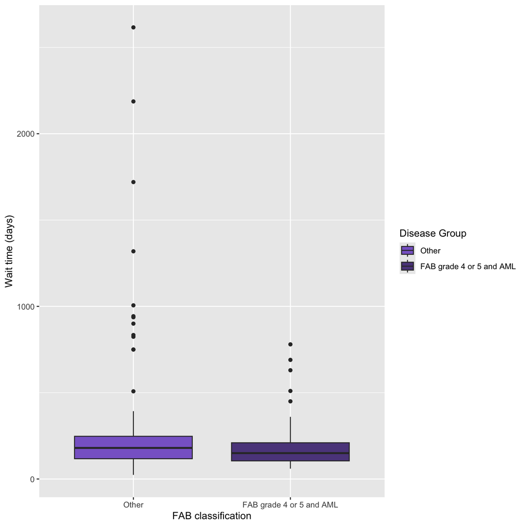

```r
# Fab - Wait time
p2 <- ggplot(bmt, aes(x = fab, y = waittime, fill=fab)) +
  geom_boxplot() +
  scale_fill_manual(values = c("mediumpurple3", "mediumpurple4")) +
  labs(x = "FAB classification",
       y = "Wait time (days)", fill = "Disease Group")

p2
```

```r
# ggsave("fab_waittime.png", plot = p2, width = 6, height = 4, dpi = 300)

vars %>%
  tbl_summary(
    by = fab,
    statistic = list(
      all_continuous() ~ "{mean} ({sd})",
      waittime ~ "{median} ({p25}, {p75})",
      all_categorical() ~ "{n} ({p}%)"), missing_text = "Missing" ) %>%
  add_p(test = list(
      all_continuous() & !waittime ~ "oneway.test",
      waittime ~ "kruskal.test")) %>%
  as_gt() %>%
  opt_table_font(
    font = list("Times New Roman")) %>%
  tab_options(
    table.font.size = px(10),
    heading.title.font.size = px(10))
```

[output not shown]

| **Characteristic** | **Other** N = 92<sup>1</sup> | **FAB grade 4 or 5 and AML** N = 45<sup>1</sup> | **p-value** |
| --- | --- | --- | --- |
| age | 29 (9) | 28 (10) |  |
| male |  |  |  |
| Female | 36 (39%) | 21 (47%) |  |
| Male | 56 (61%) | 24 (53%) |  |
| cmv |  |  |  |
| CMV Negative | 48 (52%) | 21 (47%) |  |
| CMV Positive | 44 (48%) | 24 (53%) |  |
| donorage | 29 (10) | 27 (11) |  |
| donormale |  |  |  |
| Female | 34 (37%) | 15 (33%) |  |
| Male | 58 (63%) | 30 (67%) |  |
| donorcmv |  |  |  |
| CMV Negative | 48 (52%) | 31 (69%) |  |
| CMV Positive | 44 (48%) | 14 (31%) |  |
| waittime | 180 (115, 255) | 150 (105, 210) |  |
| hospital |  |  |  |
| AHahnemann (Philadelphia, PA) | 12 (13%) | 9 (20%) |  |
| Alfred (Melbourne, Austrailia) | 14 (15%) | 3 (6.7%) |  |
| St. Vincent (Sydney, Australia) | 18 (20%) | 5 (11%) |  |
| The Ohio State University | 48 (52%) | 28 (62%) |  |
| mtx |  |  |  |
| No Prophylactic Use of Methotrexate | 60 (65%) | 37 (82%) |  |
| Prophylactic Use of Methotrexate | 32 (35%) | 8 (18%) |  |
| disgroup |  |  |  |
| ALL | 38 (41%) | 0 (0%) |  |
| AML (Low Risk) | 36 (39%) | 18 (40%) |  |
| AML (High Risk) | 18 (20%) | 27 (60%) |  |
| sex_mismatch |  |  |  |
| Match | 56 (61%) | 23 (51%) |  |
| Male->Female | 19 (21%) | 14 (31%) |  |
| Female->Male | 17 (18%) | 8 (18%) |  |
| cmv_mismatch |  |  |  |
| CMV Negative->CMV Negative | 33 (36%) | 17 (38%) |  |
| CMV Negative->CMV Positive | 15 (16%) | 14 (31%) |  |
| CMV Positive->CMV Negative | 15 (16%) | 4 (8.9%) |  |
| CMV Positive->CMV Positive | 29 (32%) | 10 (22%) |  |
| deltaa | 18 (20%) | 8 (18%) |  |
| deltas | 47 (51%) | 34 (76%) |  |
| deltar | 20 (22%) | 22 (49%) |  |

<sup>1</sup> Mean (SD); n (%); Median (Q1, Q3)